# Ozone prediction App

15 mars 2018

## Presentation of the data

My App uses **airquality** dataset (153 rows):

```
##   Ozone Solar.R Wind Temp Month Day
## 1    41     190  7.4   67     5   1
## 2    36     118  8.0   72     5   2
## 3    12     149 12.6   74     5   3
## 4    18     313 11.5   62     5   4
```

We use temperature and wind ranges to forward ozone rate depending on solar rays (only graphically). The questions are:

- When temperature increases, does ozone rate increase? decrease?
- When wind increases, does ozone rate increase? decrease?
- Does ozone increase depending to solar radiation change with other meteoroligal conditions (wind, temperature?)

## What do you see?

Using the sliders (left) you can see how the linear regression ozone depending of solar radiation operates when you wind/temperature ranges changes. It's the red line. For example with wind [1; 10] Mph and temperature [60; 80]°F:

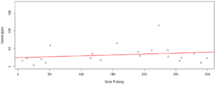

The line coefficients are:

```
## (Intercept)     Solar.R
## 24.62851413  0.05149665
```

## Discussion

- All temperatures, low wind level:

```
## (Intercept)     Solar.R
##  26.7690230   0.2232465
```

- All temperatures, high wind level:

```
## (Intercept)     Solar.R
## 15.17048528  0.05158636
```

- All wind levels, low temperature:

```
## (Intercept)     Solar.R
## 13.20485846  0.03585046
```

- All wind levels, high temperature:

```
## (Intercept)     Solar.R
## 69.68640281  0.04304516
```

Ozone rate is lower, in mean, when wind is strong or temperature is cold. It is much more depending on solar radiation when low winds.

## Conclusion

To have these coefficients, I use formulas like:

```r
subdata <- airquality[airquality$Wind >= wmin & airquality$Wind <= wmax &
                      airquality$Temp >= tmin & airquality$Temp <= tmax,]
lm(Ozone ~ Solar.R, data = subdata)$coefficients
```

```
## (Intercept)     Solar.R
##  21.0904940   0.0673985
```

I haven't shown them in all slides.

The app provides a graphic answer (red line) but no *lm* coefficients. Up to you to recalculate them.